# Data002: 乳製品ブランドデータ lvsem デモ

Analysis

2026-05-10

## 概要

このノートは、乳製品ブランドに関する公開データを使った `lvsem` のデモです。

データには、消費者満足、ブランド態度、ブランド選好、購買意図に関する回答が含まれています。 ここでは、論文で示されている構造に沿って、`CS` から `BA`、`BP`、`PI` へ、 さらに `BA` から `BP` と `PI` へ、`BP` から `PI` へ向かうモデルを推定します。

分析の流れは次の通りです。

- CSVを読み込む
- 観測変数ブロックと構造パス行列を定義する
- `lvsem` で潜在変数スコアを作成する
- パス係数、効果、R2を推定する
- bootstrapでパス係数のばらつきを確認する
- 測定モデルの信頼性、AVE、外部負荷量を確認する
- モデル図を作成する

## パッケージ

```r
rm(list = ls(all = TRUE))

library(lvsem)
library(ggplot2)
library(knitr)
```

## データ読み込み

```r
data_file <- "Data Base.csv"
data_candidates <- c(
  file.path("data002", data_file),
  data_file,
  file.path("..", "data002", data_file)
)
data_path <- data_candidates[file.exists(data_candidates)][1]

if (is.na(data_path)) {
  stop("CSVファイルが見つかりません: ", data_file)
}

data_dir <- dirname(data_path)

raw_data <- read.csv(data_path, sep = ";", check.names = TRUE)

dim(raw_data)
```

```
## [1] 195  19
```

```r
head(raw_data)
```

```
##   Gender Age MaritalStatus CS1 CS2 CS3 CS4 CS5 BP1 BP2 BP3 BP4 BA1 BA2 BA3 PI1
## 1  women  19        single   5   5   5   5   5   5   3   3   5   5   5   5   5
## 2  women  19        single   4   5   5   5   4   5   5   5   5   5   5   5   5
## 3    men  24        single   4   4   4   4   3   1   2   2   1   4   5   3   3
## 4    men  44      married    5   5   5   5   5   3   3   2   2   4   4   4   4
## 5  women  21        single   3   4   3   4   3   1   1   1   1   3   4   5   3
## 6    men  31        single   5   5   5   5   4   4   5   5   5   5   5   5   5
##   PI2 PI3 PI4
## 1   5   5   5
## 2   5   5   5
## 3   4   3   4
## 4   3   3   3
## 5   2   3   3
## 6   4   4   4
```

## モデル定義

このデモでは、次の4つの潜在変数を使います。

- `CS`: 消費者満足
- `BA`: ブランド態度
- `BP`: ブランド選好
- `PI`: 購買意図

```r
blocks <- list(
  CS = paste0("CS", 1:5),
  BA = paste0("BA", 1:3),
  BP = paste0("BP", 1:4),
  PI = paste0("PI", 1:4)
)

latent_vars <- names(blocks)
path <- matrix(
  0,
  nrow = length(latent_vars),
  ncol = length(latent_vars),
  dimnames = list(latent_vars, latent_vars)
)

path["BA", "CS"] <- 1
path["BP", c("CS", "BA")] <- 1
path["PI", c("CS", "BA", "BP")] <- 1
path
```

```
##    CS BA BP PI
## CS  0  0  0  0
## BA  1  0  0  0
## BP  1  1  0  0
## PI  1  1  1  0
```

```r
score_relation <- path + t(path)
score_relation
```

```
##    CS BA BP PI
## CS  0  1  1  1
## BA  1  0  1  1
## BP  1  1  0  1
## PI  1  1  1  0
```

## 前処理

```r
model_vars <- unique(unlist(blocks))
model_data <- raw_data[, model_vars, drop = FALSE]

model_data[] <- lapply(model_data, function(x) {
  x <- as.numeric(as.character(x))
  x[!is.finite(x)] <- NA_real_
  x
})

model_data[] <- lapply(model_data, function(x) {
  ifelse(is.na(x), stats::median(x, na.rm = TRUE), x)
})

data.frame(
  samples = nrow(model_data),
  variables = ncol(model_data)
)
```

```
##   samples variables
## 1     195        16
```

## 潜在変数スコア

```r
lv_scores <- make_lv_scores(model_data, blocks, score_relation)

head(lv_scores)
```

```
##            CS         BA         BP         PI
## 1  1.03805651  0.6105095  0.4050641  0.9846493
## 2  0.70608214  0.6105095  1.1150581  0.9846493
## 3 -0.06122641 -0.1121397 -1.3732591 -0.3688359
## 4  1.03805651 -0.1241319 -0.6619449 -0.5598812
## 5 -0.45650242 -0.1492832 -1.7282561 -1.0333737
## 6  0.89603355  0.6105095  0.9321093  0.3368683
```

```r
round(cor(lv_scores), 3)
```

```
##       CS    BA    BP    PI
## CS 1.000 0.583 0.671 0.779
## BA 0.583 1.000 0.529 0.691
## BP 0.671 0.529 1.000 0.717
## PI 0.779 0.691 0.717 1.000
```

## 構造モデル

```r
path_coefficients <- estimate_paths(lv_scores, path)
path_effects <- effects_from_beta(path_coefficients)

path_coefficients
```

```
##       path      beta
## 1 CS_to_BA 0.5827942
## 2 CS_to_BP 0.5492620
## 3 BA_to_BP 0.2089492
## 4 CS_to_PI 0.4165730
## 5 BA_to_PI 0.3002360
## 6 BP_to_PI 0.2788174
```

```r
path_effects
```

```
##   relationships    direct   indirect     total
## 1      BA -> BP 0.2089492 0.00000000 0.2089492
## 2      BA -> PI 0.3002360 0.05825867 0.3584947
## 3      BP -> PI 0.2788174 0.00000000 0.2788174
## 4      CS -> BA 0.5827942 0.00000000 0.5827942
## 5      CS -> BP 0.5492620 0.12177438 0.6710363
## 6      CS -> PI 0.4165730 0.36207242 0.7786455
```

```r
r2_values <- sapply(c("BA", "BP", "PI"), function(dv) {
  preds <- names(which(path[dv, ] == 1))
  fit <- lm(
    as.formula(paste(dv, "~", paste(preds, collapse = " + "))),
    data = as.data.frame(scale(lv_scores))
  )
  summary(fit)$r.squared
})

kable(
  data.frame(
    construct = names(r2_values),
    R2 = round(as.numeric(r2_values), 3)
  ),
  caption = "内生潜在変数のR2"
)
```

内生潜在変数のR2

| construct | R2 |
| --- | --- |
| BA | 0.340 |
| BP | 0.479 |
| PI | 0.732 |

## Bootstrap

```r
set.seed(123)
boot_paths <- bootstrap_paths(
  model_data,
  blocks,
  path,
  br = 1000,
  seed = 123,
  score_matrix = score_relation
)

kable(
  data.frame(
    path = boot_paths$path,
    round(boot_paths[, c("beta", "boot_se", "t_value")], 3)
  ),
  caption = "Bootstrapによる構造パス"
)
```

Bootstrapによる構造パス

| path | beta | boot_se | t_value |
| --- | --- | --- | --- |
| CS_to_BA | 0.583 | 0.061 | 9.512 |
| CS_to_BP | 0.549 | 0.070 | 7.881 |
| BA_to_BP | 0.209 | 0.067 | 3.137 |
| CS_to_PI | 0.417 | 0.066 | 6.318 |
| BA_to_PI | 0.300 | 0.053 | 5.666 |
| BP_to_PI | 0.279 | 0.066 | 4.252 |

## 測定モデルの要約

```r
measures <- measurement_summary(model_data, blocks, lv_scores)

kable(
  data.frame(
    block = measures$reliability$block,
    round(measures$reliability[, c("alpha", "composite_reliability", "ave")], 3)
  ),
  caption = "信頼性とAVE"
)
```

信頼性とAVE

| block | alpha | composite_reliability | ave |
| --- | --- | --- | --- |
| CS | 0.945 | 0.959 | 0.825 |
| BA | 0.927 | 0.953 | 0.872 |
| BP | 0.958 | 0.970 | 0.889 |
| PI | 0.886 | 0.923 | 0.751 |

```r
kable(
  data.frame(
    block = measures$loadings$block,
    item = measures$loadings$item,
    loading = round(measures$loadings$loading, 3)
  ),
  caption = "外部負荷量"
)
```

外部負荷量

| block | item | loading |
| --- | --- | --- |
| CS | CS1 | 0.928 |
| CS | CS2 | 0.939 |
| CS | CS3 | 0.947 |
| CS | CS4 | 0.942 |
| CS | CS5 | 0.772 |
| BA | BA1 | 0.935 |
| BA | BA2 | 0.937 |
| BA | BA3 | 0.929 |
| BP | BP1 | 0.936 |
| BP | BP2 | 0.943 |
| BP | BP3 | 0.949 |
| BP | BP4 | 0.943 |
| PI | PI1 | 0.721 |
| PI | PI2 | 0.925 |
| PI | PI3 | 0.896 |
| PI | PI4 | 0.910 |

## モデル図

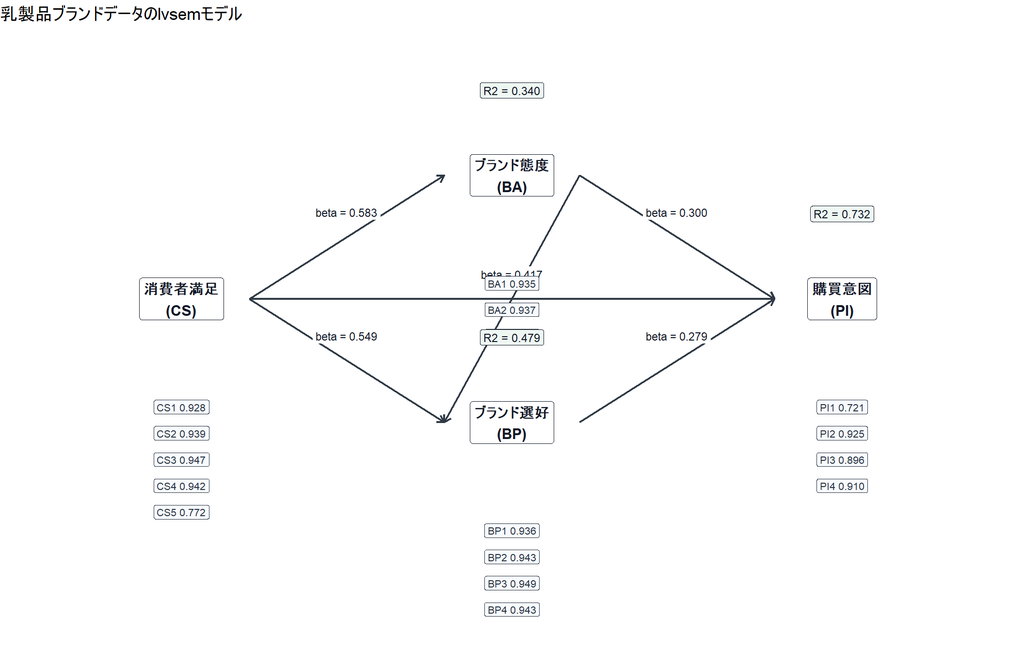

```r
node_df <- data.frame(
  block = c("CS", "BA", "BP", "PI"),
  label = c(
    "消費者満足\n(CS)",
    "ブランド態度\n(BA)",
    "ブランド選好\n(BP)",
    "購買意図\n(PI)"
  ),
  x = c(0, 2.2, 2.2, 4.4),
  y = c(1.4, 2.2, 0.6, 1.4)
)

edge_df <- path_coefficients
edge_split <- strsplit(edge_df$path, "_to_")
edge_df$from <- vapply(edge_split, `[`, character(1), 1)
edge_df$to <- vapply(edge_split, `[`, character(1), 2)
edge_df$label <- sprintf("beta = %.3f", edge_df$beta)

edge_df <- merge(
  edge_df,
  node_df[, c("block", "x", "y")],
  by.x = "from",
  by.y = "block"
)
names(edge_df)[names(edge_df) %in% c("x", "y")] <- c("x_from", "y_from")

edge_df <- merge(
  edge_df,
  node_df[, c("block", "x", "y")],
  by.x = "to",
  by.y = "block"
)
names(edge_df)[names(edge_df) %in% c("x", "y")] <- c("x_to", "y_to")

edge_df$x_label <- (edge_df$x_from + edge_df$x_to) / 2
edge_df$y_label <- (edge_df$y_from + edge_df$y_to) / 2

item_df <- measures$loadings
item_df$i <- ave(seq_len(nrow(item_df)), item_df$block, FUN = seq_along)
item_df$n <- ave(seq_len(nrow(item_df)), item_df$block, FUN = length)
item_df <- merge(item_df, node_df[, c("block", "x", "y")], by = "block")
names(item_df)[names(item_df) %in% c("x", "y")] <- c("x_node", "y_node")
item_df$x <- item_df$x_node
item_df$y <- item_df$y_node - 0.70 - (item_df$i - 1) * 0.17
item_df$label <- sprintf("%s %.3f", item_df$item, item_df$loading)

r2_df <- data.frame(
  block = names(r2_values),
  r2_label = sprintf("R2 = %.3f", as.numeric(r2_values))
)
r2_df <- merge(r2_df, node_df[, c("block", "x", "y")], by = "block")

model_plot <- ggplot() +
  geom_segment(
    data = edge_df,
    aes(x = x_from + 0.45, y = y_from, xend = x_to - 0.45, yend = y_to),
    arrow = arrow(length = unit(0.22, "cm")),
    linewidth = 0.8,
    color = "#2f3a45"
  ) +
  geom_label(
    data = node_df,
    aes(x = x, y = y, label = label),
    size = 4.1,
    fontface = "bold",
    label.size = 0.35,
    fill = "#ffffff",
    color = "#111827"
  ) +
  geom_label(
    data = edge_df,
    aes(x = x_label, y = y_label + 0.16, label = label),
    size = 3,
    label.size = 0,
    fill = "#ffffff",
    color = "#111827"
  ) +
  geom_label(
    data = item_df,
    aes(x = x, y = y, label = label),
    size = 2.8,
    label.size = 0.2,
    fill = "#f7fbff",
    color = "#2a3340"
  ) +
  geom_label(
    data = r2_df,
    aes(x = x, y = y + 0.55, label = r2_label),
    size = 3.1,
    label.size = 0.25,
    fill = "#eef7f2",
    color = "#111827"
  ) +
  coord_cartesian(xlim = c(-0.9, 5.3), ylim = c(-0.7, 3.0), clip = "off") +
  theme_void() +
  labs(title = "乳製品ブランドデータのlvsemモデル")

model_plot
```

```r
ggsave(file.path(data_dir, "data002_lvsem_brand_model.png"),
       model_plot, width = 11, height = 7, dpi = 180)
```

## 出力の確認

```r
cat("サンプルサイズ:", nrow(model_data), "\n")
```

```
## サンプルサイズ: 195
```

```r
print(round(r2_values, 3))
```

```
##    BA    BP    PI
## 0.340 0.479 0.732
```

## 参考

- Boubker & Douayri (2020), Data in Brief, DOI: 10.1016/j.dib.2020.106172
- ローカルパッケージ: `lvsem`
- データ: `Data Base.csv`